# Prediction Assignment Writeup

Luiz Marcelo V Vieira

July 3, 2018

## Introduction

Using devices such as Jawbone Up, Nike FuelBand, and Fitbit it is now possible to collect a large amount of data about personal activity relatively inexpensively. These type of devices are part of the quantified self movement that a group of enthusiasts who take measurements about themselves regularly to improve their health, to find patterns in their behavior, or because they are tech geeks. One thing that people regularly do is quantify how much of a particular activity they do, but they rarely quantify how well they do it. In this project, your goal will be to use data from accelerometers on the belt, forearm, arm, and dumbell of 6 participants. They were asked to perform barbell lifts correctly and incorrectly in 5 different ways. More information is available from the website here http://web.archive.org/web/20161224072740/http:/groupware.les.inf.puc-rio.br/har

## Load library

```r
library(ggplot2)
library(caret)
library(rpart)
library(rattle)
library(rpart.plot)
library(randomForest)
library(gbm)
```

## Data

The training data for this project are available here: https://d396qusza40orc.cloudfront.net/predmachlearn/pml-training.csv

The test data are available here: https://d396qusza40orc.cloudfront.net/predmachlearn/pml-testing.csv

```r
setwd("D:\\projetos\\data-science")

if (!file.exists("pml-training.csv")) {
  URLTrain <- "https://d396qusza40orc.cloudfront.net/predmachlearn/pml-training.csv"
  download.file(URLTrain, destfile = "pml-training.csv")
}

if (!file.exists("pml-testing.csv")) {
  URLTest <- "https://d396qusza40orc.cloudfront.net/predmachlearn/pml-testing.csv"
  download.file(URLTest, destfile = "pml-testing.csv")
}
```

## Loading Data

```r
training <- read.csv(file="pml-training.csv", na.strings=c("NA","#DIV/0!",""))
testing <- read.csv(file="pml-testing.csv", na.strings=c("NA","#DIV/0!",""))
dim(training); dim(testing)
```

```
## [1] 19622   160
```

```
## [1]  20 160
```

## Cleaning Data

The first 7 columns are variables that has no relationship with “classe”

```r
training <- training[, colSums(is.na(training))== 0]
testing <- testing[, colSums(is.na(testing))== 0]
training <- training[,-c(1:7)]
testing <- testing[,-c(1:7)]
dim(training); dim(testing)
```

```
## [1] 19622    53
```

```
## [1] 20 53
```

## Training, Test, and Validation Data

The most three popular prediction models will be applied in the training dataset and the one with the best accuracy is going to be used for prediction over the testing dataset. The training data set is split in 2 parts whose rate is 70% for training and 30% for validating all three models. Those methods are Decision Tree, Random Forest, and Generalized Boosted Model.

```r
set.seed(411)
inTrain  <- createDataPartition(training$classe, p=0.7, list=FALSE)
trainSet <- training[inTrain, ]
testSet  <- training[-inTrain, ]
dim(trainSet); dim(testSet)
```

```
## [1] 13737    53
```

```
## [1] 5885   53
```

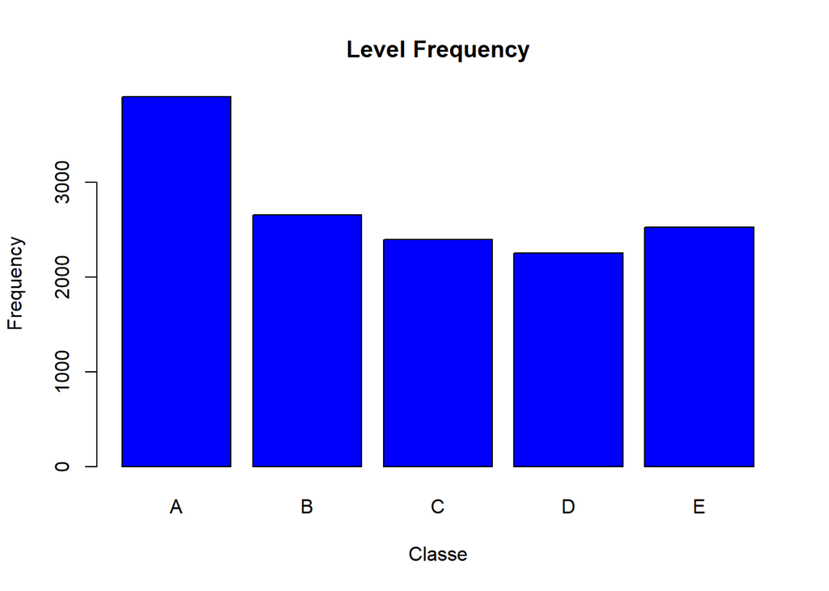

```r
plot(trainSet$classe, col="blue", main="Level Frequency", xlab="Classe", ylab="Frequency")
```

# Decision Tree

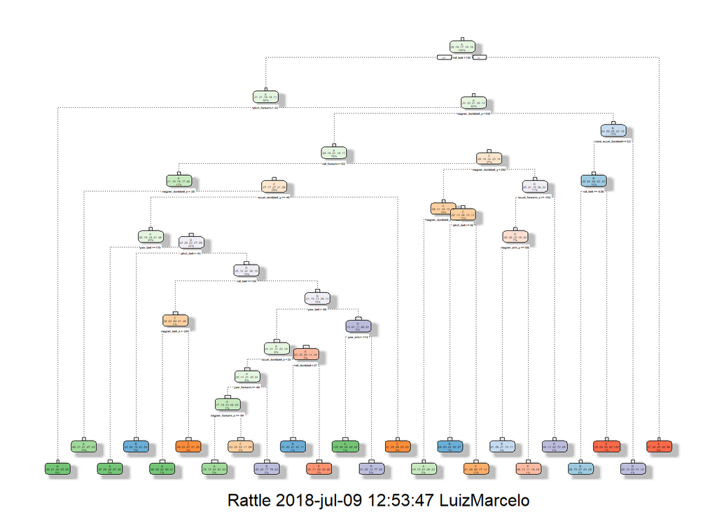

```r
set.seed(410)
dTM <- rpart(classe ~ ., data = trainSet, method = "class")
fancyRpartPlot(dTM)
```

```r
dTP <- predict(dTM, newdata=testSet, type="class")
cTree <- confusionMatrix(dTP, testSet$classe)
cTree
```

```
## Confusion Matrix and Statistics
##
##           Reference
## Prediction    A    B    C    D    E
##          A 1536  234   26  103   65
##          B   47  647   94   29   72
##          C   42  114  818  163  117
##          D   29   81   64  602   58
##          E   20   63   24   67  770
##
## Overall Statistics
##
##                Accuracy : 0.7431
##                  95% CI : (0.7317, 0.7542)
##     No Information Rate : 0.2845
##     P-Value [Acc > NIR] : < 2.2e-16
##
##                   Kappa : 0.6731
##  Mcnemar's Test P-Value : < 2.2e-16
##
## Statistics by Class:
##
##                      Class: A Class: B Class: C Class: D Class: E
## Sensitivity            0.9176   0.5680   0.7973   0.6245   0.7116
## Specificity            0.8984   0.9490   0.9103   0.9529   0.9638
## Pos Pred Value         0.7821   0.7278   0.6523   0.7218   0.8157
## Neg Pred Value         0.9648   0.9015   0.9551   0.9283   0.9369
## Prevalence             0.2845   0.1935   0.1743   0.1638   0.1839
## Detection Rate         0.2610   0.1099   0.1390   0.1023   0.1308
## Detection Prevalence   0.3337   0.1511   0.2131   0.1417   0.1604
## Balanced Accuracy      0.9080   0.7585   0.8538   0.7887   0.8377
```

# Random Forest

```r
set.seed(411)
controlRF <- trainControl(method="cv", 5)
modFitRF <- train(classe ~ ., data=trainSet, method="rf", trControl=controlRF)
modFitRF$finalModel
```

```
##
## Call:
##  randomForest(x = x, y = y, mtry = param$mtry)
##                Type of random forest: classification
##                      Number of trees: 500
## No. of variables tried at each split: 2
##
##         OOB estimate of  error rate: 0.76%
## Confusion matrix:
##      A    B    C    D    E class.error
## A 3901    5    0    0    0 0.001280082
## B   14 2634   10    0    0 0.009029345
## C    0   23 2370    3    0 0.010851419
## D    0    0   41 2207    4 0.019982238
## E    0    0    2    3 2520 0.001980198
```

```r
predictRF <- predict(modFitRF, newdata=testSet)
confMatRF <- confusionMatrix(predictRF, testSet$classe)
confMatRF
```

```
## Confusion Matrix and Statistics
##
##           Reference
## Prediction    A    B    C    D    E
##          A 1674    4    0    0    0
##          B    0 1130    3    0    0
##          C    0    5 1021   17    0
##          D    0    0    2  946    2
##          E    0    0    0    1 1080
##
## Overall Statistics
##
##                Accuracy : 0.9942
##                  95% CI : (0.9919, 0.996)
##     No Information Rate : 0.2845
##     P-Value [Acc > NIR] : < 2.2e-16
##
##                   Kappa : 0.9927
##  Mcnemar's Test P-Value : NA
##
## Statistics by Class:
##
##                      Class: A Class: B Class: C Class: D Class: E
## Sensitivity            1.0000   0.9921   0.9951   0.9813   0.9982
## Specificity            0.9991   0.9994   0.9955   0.9992   0.9998
## Pos Pred Value         0.9976   0.9974   0.9789   0.9958   0.9991
## Neg Pred Value         1.0000   0.9981   0.9990   0.9964   0.9996
## Prevalence             0.2845   0.1935   0.1743   0.1638   0.1839
## Detection Rate         0.2845   0.1920   0.1735   0.1607   0.1835
## Detection Prevalence   0.2851   0.1925   0.1772   0.1614   0.1837
## Balanced Accuracy      0.9995   0.9957   0.9953   0.9903   0.9990
```

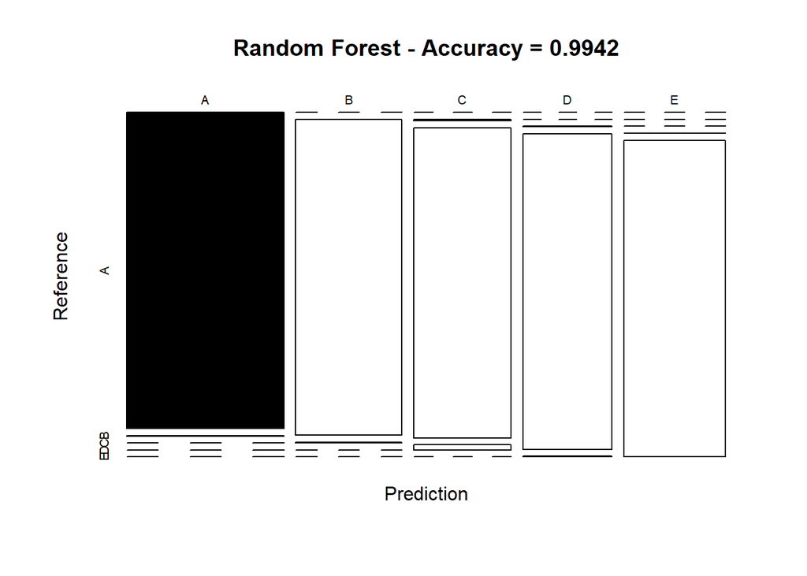

```r
plot(confMatRF$table, col = confMatRF$byClass,
     main = paste("Random Forest - Accuracy =",
                  round(confMatRF$overall['Accuracy'], 4)))
```

# Generalized Boosted Model (GBM)

```r
set.seed(411)
controlGBM <- trainControl(method = "repeatedcv", number = 5, repeats = 1)
modFitGBM  <- train(classe ~ ., data=trainSet, method = "gbm", trControl = controlGBM, verbose = FALSE)
modFitGBM$finalModel
```

```
## A gradient boosted model with multinomial loss function.
## 150 iterations were performed.
## There were 52 predictors of which 42 had non-zero influence.
```

```r
predictGBM <- predict(modFitGBM, newdata=testSet)
confMatGBM <- confusionMatrix(predictGBM, testSet$classe)
confMatGBM
```

```
## Confusion Matrix and Statistics
##
##           Reference
## Prediction    A    B    C    D    E
##          A 1637   31    0    1    2
##          B   25 1068   25    3    9
##          C    3   40  980   35    8
##          D    8    0   21  919   12
##          E    1    0    0    6 1051
##
## Overall Statistics
##
##                Accuracy : 0.9609
##                  95% CI : (0.9556, 0.9657)
##     No Information Rate : 0.2845
##     P-Value [Acc > NIR] : < 2.2e-16
##
##                   Kappa : 0.9506
##  Mcnemar's Test P-Value : 3.256e-05
##
## Statistics by Class:
##
##                      Class: A Class: B Class: C Class: D Class: E
## Sensitivity            0.9779   0.9377   0.9552   0.9533   0.9713
## Specificity            0.9919   0.9869   0.9823   0.9917   0.9985
## Pos Pred Value         0.9797   0.9451   0.9193   0.9573   0.9934
## Neg Pred Value         0.9912   0.9851   0.9905   0.9909   0.9936
## Prevalence             0.2845   0.1935   0.1743   0.1638   0.1839
## Detection Rate         0.2782   0.1815   0.1665   0.1562   0.1786
## Detection Prevalence   0.2839   0.1920   0.1811   0.1631   0.1798
## Balanced Accuracy      0.9849   0.9623   0.9687   0.9725   0.9849
```

## Applying the best model to the Test dataset

Accuracy of the 3 models: Random Forest: 0.9942 GBM : 0.9609 Decision Tree: 0.7431

```r
predictValTest <- predict(modFitRF, newdata=testing)
predictValTest
```

```
##  [1] B A B A A E D B A A B C B A E E A B B B
## Levels: A B C D E
```